# Colorado_Flood_Clusters

Marcela

11/12/2019

## **Analysis with a subset of the data**

#### **Data Cleaning**

Besides the data cleaning already applied to the full dataset and explained in the “Colorado_Fulldataset” document, in this stage we removed tweets sent by Twitter accounts from official agencies since we aim to analyze what general public post. In this stage **6%** of the tweets were excluded. 228 tweets from the 4086 total tweets.

Now I will repeat the same analysis but considering tweets sent from what should be the “affected area” (by using spatial clustering) and within the Flood phase of the disaster.

Before doing so, the data was first projected in North America Lambert Conformal Conic.

```
## Coordinate Reference System:
##   No EPSG code
##   proj4string: "+proj=lcc +lat_1=20 +lat_2=60 +lat_0=40 +lon_0=-96 +x_0=0 +y_0=0 +ellps=GRS80 +towgs84=0,0,0,0,0,0,0 +units=m +no_defs"
```

#### **Subsetting by Spatial Clustering**

In order to identify tweets sent from the afected area, a hierarchical implementation of dbscan was used **(hdscan)**. For spatial hierarchical clustering we need to pick a number of minimum points to be considered to identify the cluster. When setting that number with any value betweet 315 and 340, clusters in Colorado were identify. So we picked the minimum value in that range: **315**.

[interactive chart not shown]

##### **Most common words (Within Spatial Clusters)**

After the spatial filter and filtering only tweets sent during the Flood stage only **16%** of the total tweets were retained. 652 tweets from the 4086 total.

A quick view of the most common words in the whole dataset:

```
## # A tibble: 1,762 x 2
##    word             n
##    <chr>        <int>
##  1 boulder        359
##  2 boulderflood   268
##  3 cowx           133
##  4 flood           81
##  5 rain            77
##  6 flooding        67
##  7 creek           53
##  8 rt              47
##  9 water           47
## 10 amp             38
## # … with 1,752 more rows
```

```
## # A tibble: 1,755 x 2
##    word         n
##    <chr>    <int>
##  1 flood       81
##  2 rain        77
##  3 flooding    67
##  4 creek       53
##  5 water       47
##  6 colorado    37
##  7 stay        30
##  8 safe        28
##  9 closed      27
## 10 denver      25
## # … with 1,745 more rows
```

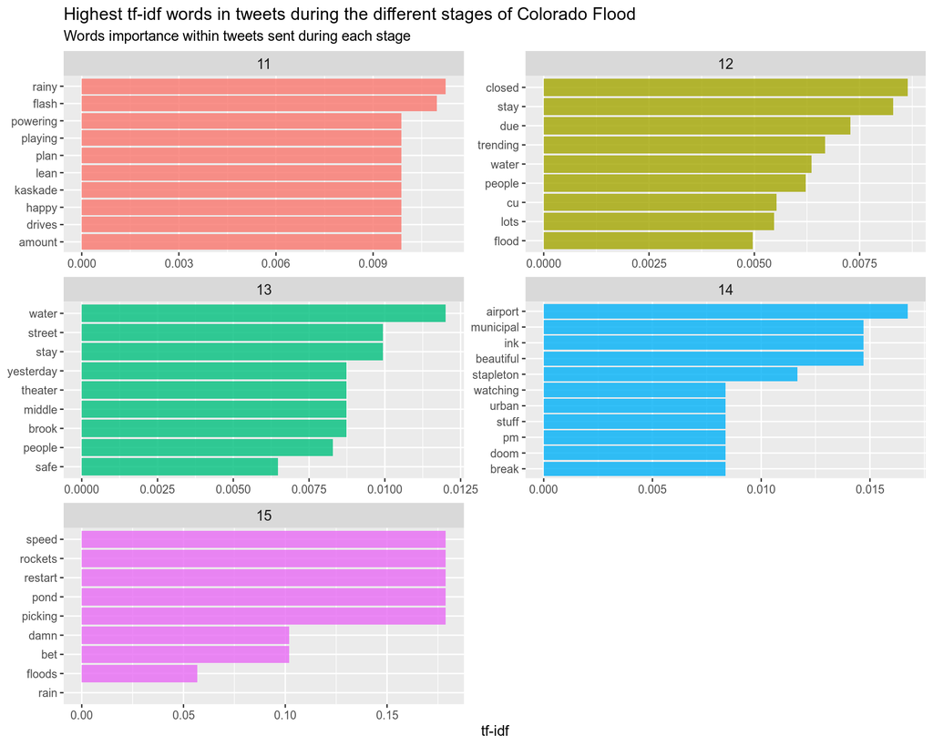

##### **Topic Modeling**

[figure not shown]

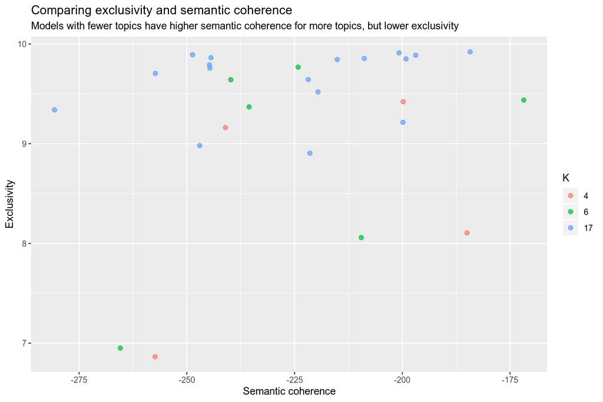

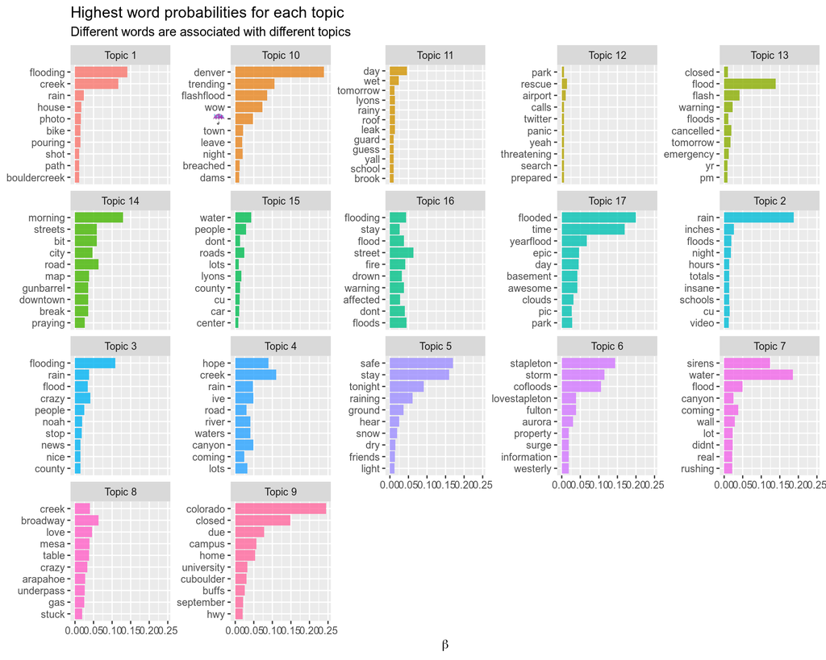

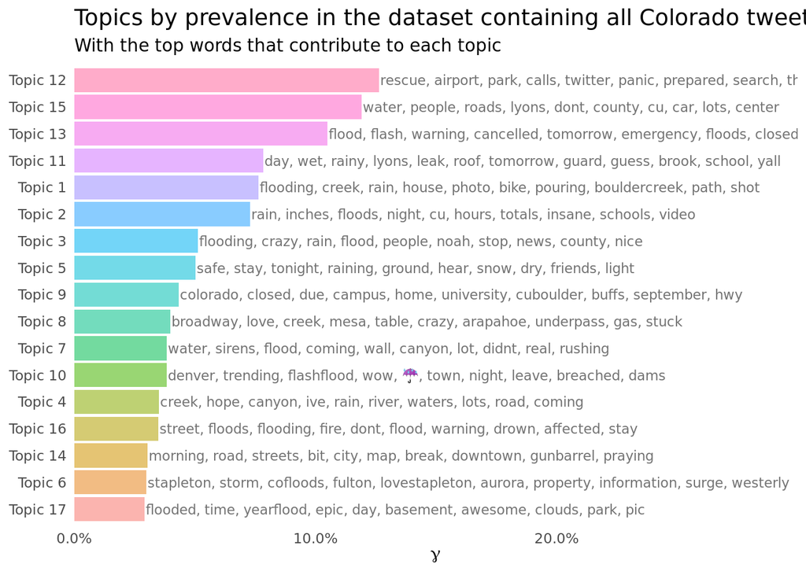

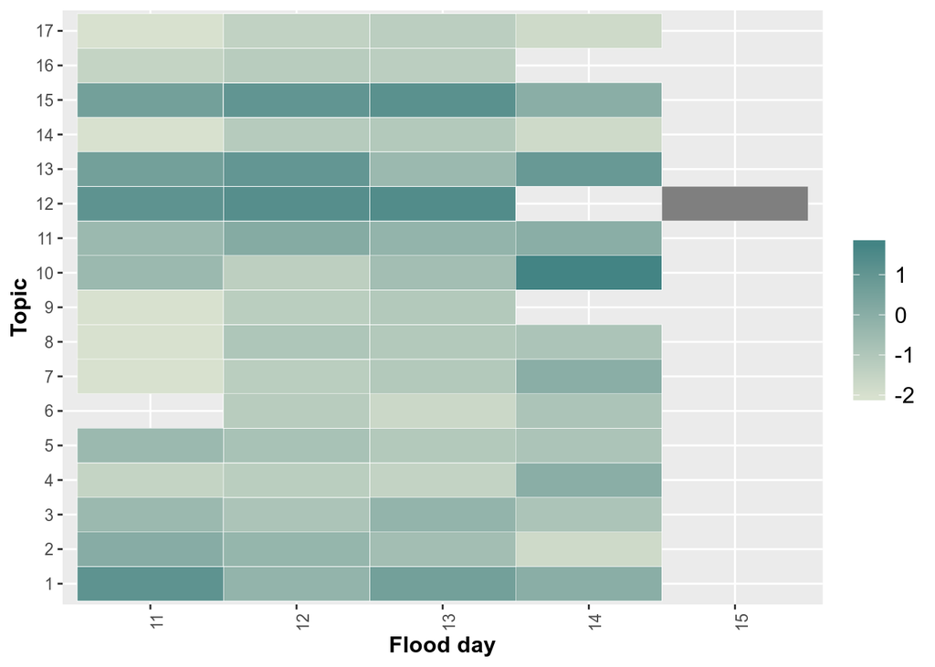

Mapping topic 12 to see spatial distribution:

[interactive chart not shown]